# Project Python Foundations: FoodHub Data Analysis

### **Question 12**: Perform a multivariate analysis to explore relationships between the important variables in the dataset. (It is a good idea to explore relations between numerical variables as well as relations between numerical and categorical variables) [10 marks]

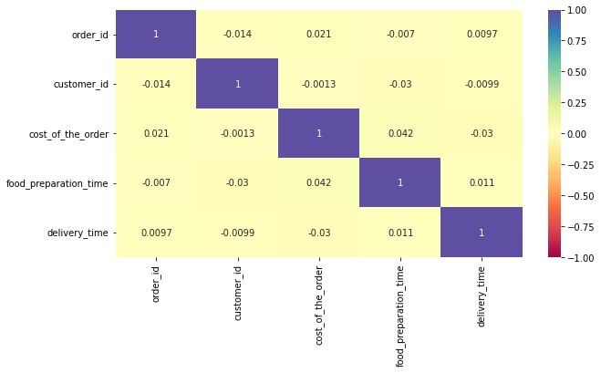

```python
#let's observe the correlation between all the numerical variables
plt.figure(figsize=(10,5));
sns.heatmap(df.corr(),annot=True,cmap='Spectral',vmin=-1,vmax=1);
```

Observations:

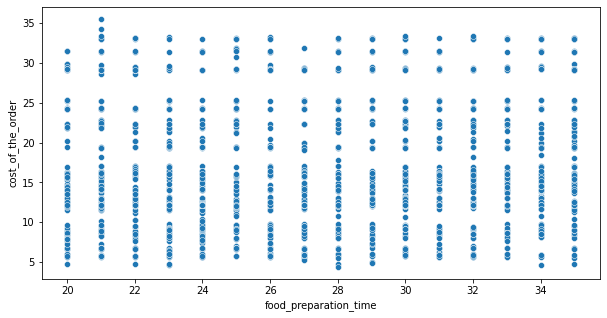

```python
#we can prove above via a scatterplot and rest with a pairplot
plt.figure(figsize = (10,5));
sns.scatterplot(data=df,x='food_preparation_time',y='cost_of_the_order');
```

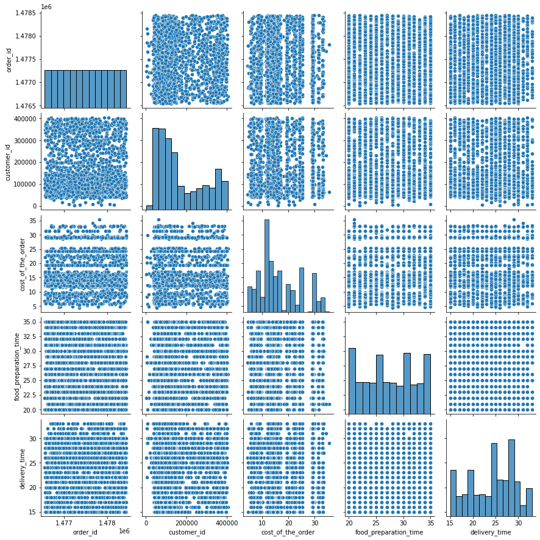

```python
sns.pairplot(data=df);
```

- As observed, nothing can be concluded by just observing the numerical variables.

*Let's observe the relation between cuisine and various numerical variables*

**Cuisine & Cost of the Order**

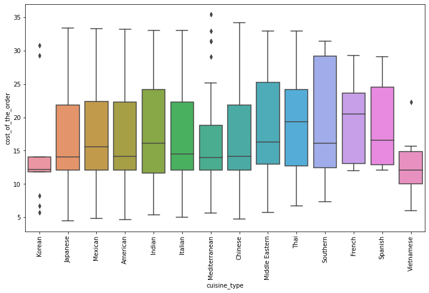

```python
plt.figure(figsize=(12,7))
sns.boxplot(data=df,x='cuisine_type',y='cost_of_the_order');
plt.xticks(rotation=90);
```

- More than 75% of the orders for all cuisines are more than 10 dollars with median at 14 dollars.
- Mediterranean food has a few outliers with maximum cost of 35 dollars.

**Cuisine & Food Preparation Time**

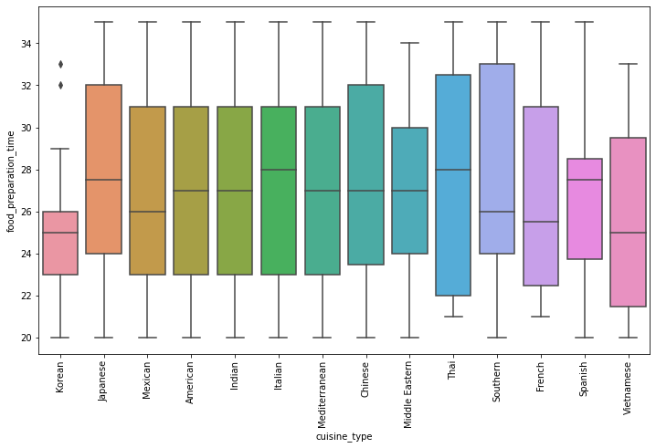

```python
plt.figure(figsize=(12,7))
sns.boxplot(data=df,x='cuisine_type',y='food_preparation_time');
plt.xticks(rotation=90);
```

```python
df.groupby(['cuisine_type'])['food_preparation_time'].median().sort_values()
```

```
cuisine_type
Korean            25.0
Vietnamese        25.0
French            25.5
Mexican           26.0
Southern          26.0
American          27.0
Chinese           27.0
Indian            27.0
Mediterranean     27.0
Middle Eastern    27.0
Japanese          27.5
Spanish           27.5
Italian           28.0
Thai              28.0
Name: food_preparation_time, dtype: float64
```

- Almost 50% of the orders for all cuisines take more than 25 minutes to prepare with the median at 27.
- Italian and Thai food takes the maximum time to prepare.

**Cuisine and Delivery Time**

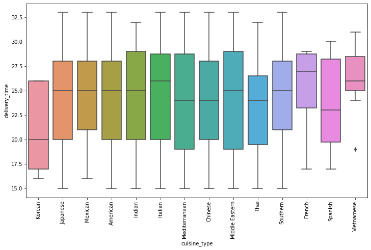

```python
plt.figure(figsize=(12,7))
sns.boxplot(data=df,x='cuisine_type',y='delivery_time');
plt.xticks(rotation=90);
```

```python
df.groupby(['cuisine_type'])['delivery_time'].median().sort_values()
```

```
cuisine_type
Korean            20.0
Spanish           23.0
Chinese           24.0
Mediterranean     24.0
Thai              24.0
American          25.0
Indian            25.0
Japanese          25.0
Mexican           25.0
Middle Eastern    25.0
Southern          25.0
Italian           26.0
Vietnamese        26.0
French            27.0
Name: delivery_time, dtype: float64
```

- Korean median delivery time is the least at 20 minutes.

*Let's observe day of the week with all numerical variables.*

**Day & Cost of the Order**

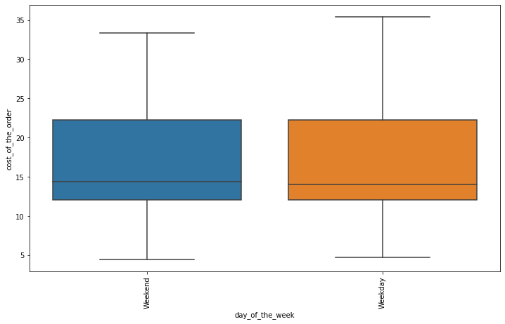

```python
plt.figure(figsize=(12,7))
sns.boxplot(data=df,x='day_of_the_week',y='cost_of_the_order');
plt.xticks(rotation=90);
```

**Day & Food Preparation Time**

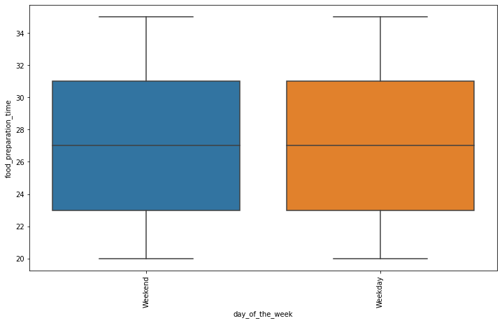

```python
plt.figure(figsize=(12,7))
sns.boxplot(data=df,x='day_of_the_week',y='food_preparation_time');
plt.xticks(rotation=90);
```

- Cost of the food and preparation time is not going to change with respect to the day.

**Day & Delivery Time**

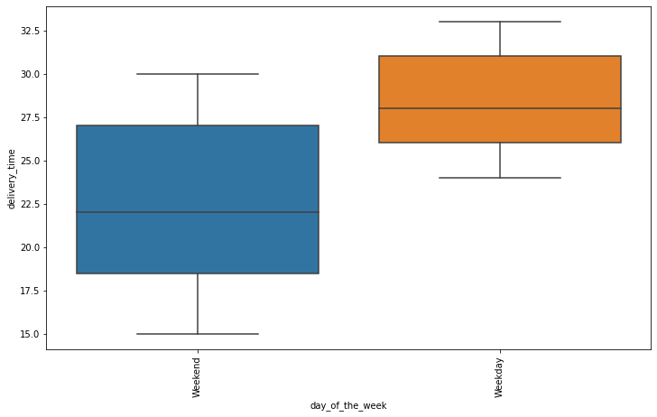

```python
plt.figure(figsize=(12,7))
sns.boxplot(data=df,x='day_of_the_week',y='delivery_time');
plt.xticks(rotation=90);
```

```python
df.groupby(['day_of_the_week'])['order_id'].count()
```

```
day_of_the_week
Weekday     547
Weekend    1351
Name: order_id, dtype: int64
```

- The delivery time is significantly higher on a weekday than the weekend with a median of around 28 on a weekday and 22 on a weekend.
- Although the number of total orders are higher on a weekend, delivery time is low.

*Let's observe the relation between rating and all numerical variables.*

**Rating & Cost of the Food**

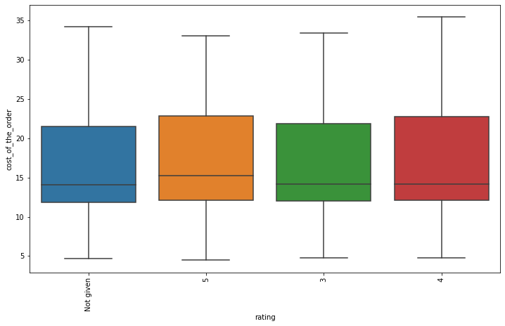

```python
plt.figure(figsize=(12,7));
sns.boxplot(data=df,x='rating',y='cost_of_the_order');
plt.xticks(rotation=90);
```

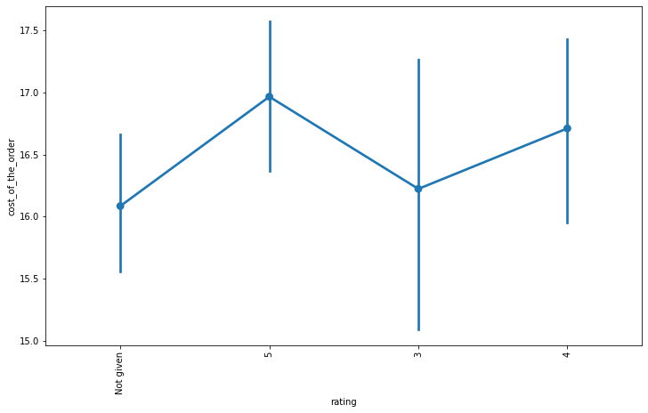

```python
#since the median are very close to each other we can observe pointplot to see how rating is changing with cost of the order
plt.figure(figsize=(12,7))
sns.pointplot(data=df,x='rating',y='cost_of_the_order');
plt.xticks(rotation=90);
```

**Rating & Food Preparation Time**

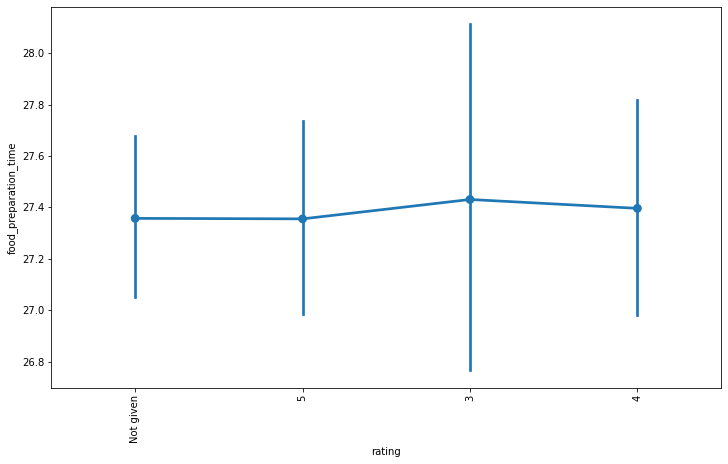

```python
plt.figure(figsize=(12,7))
sns.pointplot(data=df,x='rating',y='food_preparation_time');
plt.xticks(rotation=90);
```

- Food preparation time is almost similar for all ratings.

**Rating & Delivery Time**

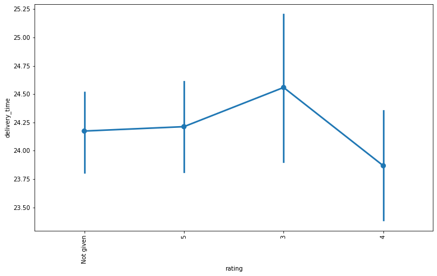

```python
plt.figure(figsize=(12,7))
sns.pointplot(data=df,x='rating',y='delivery_time');
plt.xticks(rotation=90);
```

- Rating 3 has the maximum delivery time which makes sense since people don't like to wait more for their food.

### **Question 13:** The company wants to provide a promotional offer in the advertisement of the restaurants. The condition to get the offer is that the restaurants must have a rating count of more than 50 and the average rating should be greater than 4. Find the restaurants fulfilling the criteria to get the promotional offer. [3 marks]

```python
#removing all the 'Not given' rating from the rating column
non_ng_ratings = df[df['rating'] != 'Not given'].copy()
non_ng_ratings
```

|  | order_id | customer_id | restaurant_name | cuisine_type | cost_of_the_order | day_of_the_week | rating | food_preparation_time | delivery_time |
| --- | --- | --- | --- | --- | --- | --- | --- | --- | --- |
| 2 | 1477070 | 66393 | Cafe Habana | Mexican | 12.23 | Weekday | 5 | 23 | 28 |
| 3 | 1477334 | 106968 | Blue Ribbon Fried Chicken | American | 29.20 | Weekend | 3 | 25 | 15 |
| 4 | 1478249 | 76942 | Dirty Bird to Go | American | 11.59 | Weekday | 4 | 25 | 24 |
| 5 | 1477224 | 147468 | Tamarind TriBeCa | Indian | 25.22 | Weekday | 3 | 20 | 24 |
| 7 | 1477859 | 89574 | Barbounia | Mediterranean | 5.97 | Weekday | 3 | 33 | 30 |
| ... | ... | ... | ... | ... | ... | ... | ... | ... | ... |
| 1889 | 1478190 | 94152 | RedFarm Broadway | Chinese | 8.68 | Weekday | 3 | 33 | 30 |
| 1890 | 1477316 | 164776 | TAO | Japanese | 15.67 | Weekend | 5 | 20 | 22 |
| 1893 | 1476701 | 292602 | Chipotle Mexican Grill $1.99 Delivery | Mexican | 22.31 | Weekend | 5 | 31 | 17 |
| 1894 | 1477421 | 397537 | The Smile | American | 12.18 | Weekend | 5 | 31 | 19 |
| 1896 | 1477513 | 64151 | Jack's Wife Freda | Mediterranean | 12.18 | Weekday | 5 | 23 | 31 |

1162 rows × 9 columns

```python
#since we need to perform caculations on the same, we need to convert the object type rating column to numerical type
non_ng_ratings['rating'] = non_ng_ratings['rating'].astype('int')
```

```python
#counting the number of ratings with respect to the restaurants
total_ratings = non_ng_ratings.groupby(['restaurant_name'])['rating'].count().sort_values(ascending=False).reset_index()
total_ratings.head(10)
```

|  | restaurant_name | rating |
| --- | --- | --- |
| 0 | Shake Shack | 133 |
| 1 | The Meatball Shop | 84 |
| 2 | Blue Ribbon Sushi | 73 |
| 3 | Blue Ribbon Fried Chicken | 64 |
| 4 | RedFarm Broadway | 41 |
| 5 | Parm | 39 |
| 6 | RedFarm Hudson | 34 |
| 7 | TAO | 28 |
| 8 | Rubirosa | 24 |
| 9 | Nobu Next Door | 23 |

```python
#filtering restaurants with ratings greater than 50
ratings_greater_50 = total_ratings[total_ratings['rating'] > 50]['restaurant_name']
ratings_greater_50
```

```
0                  Shake Shack
1            The Meatball Shop
2            Blue Ribbon Sushi
3    Blue Ribbon Fried Chicken
Name: restaurant_name, dtype: object
```

```python
#filtering all the above restaurants from the the entire dataset
average_4 = non_ng_ratings[non_ng_ratings['restaurant_name'].isin(ratings_greater_50)].copy().reset_index()
average_4
```

|  | index | order_id | customer_id | restaurant_name | cuisine_type | cost_of_the_order | day_of_the_week | rating | food_preparation_time | delivery_time |
| --- | --- | --- | --- | --- | --- | --- | --- | --- | --- | --- |
| 0 | 3 | 1477334 | 106968 | Blue Ribbon Fried Chicken | American | 29.20 | Weekend | 3 | 25 | 15 |
| 1 | 12 | 1476966 | 129969 | Blue Ribbon Fried Chicken | American | 24.30 | Weekend | 5 | 23 | 17 |
| 2 | 15 | 1477414 | 66222 | Shake Shack | American | 16.20 | Weekend | 5 | 33 | 25 |
| 3 | 19 | 1477354 | 67487 | Blue Ribbon Sushi | Japanese | 16.20 | Weekend | 4 | 35 | 26 |
| 4 | 22 | 1478287 | 150599 | Shake Shack | American | 29.10 | Weekday | 5 | 21 | 30 |
| ... | ... | ... | ... | ... | ... | ... | ... | ... | ... | ... |
| 349 | 1880 | 1477466 | 222734 | Shake Shack | American | 13.97 | Weekend | 5 | 35 | 27 |
| 350 | 1884 | 1477437 | 304993 | Shake Shack | American | 31.43 | Weekend | 3 | 31 | 24 |
| 351 | 1885 | 1477550 | 97324 | Shake Shack | American | 29.05 | Weekday | 4 | 27 | 29 |
| 352 | 1886 | 1478277 | 48282 | The Meatball Shop | American | 14.50 | Weekend | 5 | 34 | 25 |
| 353 | 1888 | 1477353 | 106324 | The Meatball Shop | Italian | 16.20 | Weekend | 5 | 21 | 26 |

354 rows × 10 columns

```python
#restaurants with mean rating greater than 4
average_4.groupby(['restaurant_name'])['rating'].mean().sort_values(ascending=False)
```

```
restaurant_name
The Meatball Shop            4.511905
Blue Ribbon Fried Chicken    4.328125
Shake Shack                  4.278195
Blue Ribbon Sushi            4.219178
Name: rating, dtype: float64
```

### **Question 14:** The company charges the restaurant 25% on the orders having cost greater than 20 dollars and 15% on the orders having cost greater than 5 dollars. Find the net revenue generated by the company across all orders. [3 marks]

```python
#calulating the total cost of the order for each restaurant
df.groupby(['restaurant_name'])['cost_of_the_order'].sum().sort_values(ascending=False).head(10)
```

```
restaurant_name
Shake Shack                      3579.53
The Meatball Shop                2145.21
Blue Ribbon Sushi                1903.95
Blue Ribbon Fried Chicken        1662.29
Parm                             1112.76
RedFarm Broadway                  965.13
RedFarm Hudson                    921.21
TAO                               834.50
Han Dynasty                       755.29
Blue Ribbon Sushi Bar & Grill     666.62
Name: cost_of_the_order, dtype: float64
```

```python
#defining a function to meet the required calculation
def cal_revenue(x):
  if x>20:
    return 0.25*x
  elif x>5:
    return 0.15*x
  else:
    return 0*x

#applying the function to calculate the net revenue and include it as a column
df['revenue'] = df['cost_of_the_order'].apply(cal_revenue)
df.head()
```

|  | order_id | customer_id | restaurant_name | cuisine_type | cost_of_the_order | day_of_the_week | rating | food_preparation_time | delivery_time | revenue |
| --- | --- | --- | --- | --- | --- | --- | --- | --- | --- | --- |
| 0 | 1477147 | 337525 | Hangawi | Korean | 30.75 | Weekend | Not given | 25 | 20 | 7.6875 |
| 1 | 1477685 | 358141 | Blue Ribbon Sushi Izakaya | Japanese | 12.08 | Weekend | Not given | 25 | 23 | 1.8120 |
| 2 | 1477070 | 66393 | Cafe Habana | Mexican | 12.23 | Weekday | 5 | 23 | 28 | 1.8345 |
| 3 | 1477334 | 106968 | Blue Ribbon Fried Chicken | American | 29.20 | Weekend | 3 | 25 | 15 | 7.3000 |
| 4 | 1478249 | 76942 | Dirty Bird to Go | American | 11.59 | Weekday | 4 | 25 | 24 | 1.7385 |

```python
#calculating net revenue by adding the revenue column
round(df['revenue'].sum(),2)
```

```
6166.3
```

#### Observations:

- The net revenue generated by the company across all orders is $6166.30.

### **Question 15:** The company wants to analyze the total time required to deliver the food. What percentage of orders take more than 60 minutes to get delivered from the time the order is placed? (The food has to be prepared and then delivered.) [2 marks]

```python
#adding 2 parameters mentioned below to get the total time to deliver
df['total_time_to_deliver'] = df['food_preparation_time'] + df['delivery_time']
df.head()
```

|  | order_id | customer_id | restaurant_name | cuisine_type | cost_of_the_order | day_of_the_week | rating | food_preparation_time | delivery_time | revenue | total_time_to_deliver |
| --- | --- | --- | --- | --- | --- | --- | --- | --- | --- | --- | --- |
| 0 | 1477147 | 337525 | Hangawi | Korean | 30.75 | Weekend | Not given | 25 | 20 | 7.6875 | 45 |
| 1 | 1477685 | 358141 | Blue Ribbon Sushi Izakaya | Japanese | 12.08 | Weekend | Not given | 25 | 23 | 1.8120 | 48 |
| 2 | 1477070 | 66393 | Cafe Habana | Mexican | 12.23 | Weekday | 5 | 23 | 28 | 1.8345 | 51 |
| 3 | 1477334 | 106968 | Blue Ribbon Fried Chicken | American | 29.20 | Weekend | 3 | 25 | 15 | 7.3000 | 40 |
| 4 | 1478249 | 76942 | Dirty Bird to Go | American | 11.59 | Weekday | 4 | 25 | 24 | 1.7385 | 49 |

```python
#filtering total time to deliver which is greater than 60 minutes
time_greater_60 = df[df['total_time_to_deliver']>60]
```

```python
#calulating the percentage
percentage = ((time_greater_60.shape[0])/(df.shape[0]))*100
round(percentage,2)
```

```
10.54
```

#### Observations:

- As seen above, 10.54% of the orders take more than 60 minutes to get delivered. That means, most of the restaurants deliver food in less than an hour.

### **Question 16:** The company wants to analyze the delivery time of the orders on weekdays and weekends. How does the mean delivery time vary during weekdays and weekends? [2 marks]

```python
round(df.groupby(['day_of_the_week'])['delivery_time'].mean())
```

```
day_of_the_week
Weekday    28.0
Weekend    22.0
Name: delivery_time, dtype: float64
```

#### Observations:

- During the weekday the delivery time is comparatively higher than on the weekend. Though the number of orders on the weekend is higher, company tend to work on a faster pace to cope up the demand.

### Conclusion and Recommendations

### **Question 17:** What are your conclusions from the analysis? What recommendations would you like to share to help improve the business? (You can use cuisine type and feedback ratings to drive your business recommendations.) [6 marks]

### Conclusions:

- Out of all 178 unique restaurants, Shake Shack, an American cuisine restaurant, has the most numbers of orders received.
- Next most favoured cuisine for the customers is Japanese.
- American and Japanese cuisine restaurants comprises of total of about 56% of all the orders.
- Least prefered cuisines amongst the customers are Vietnamese and Korean.
- 31% of the customers prefer American cuisine.
- Most numbers of orders are received during the weekends about 71%.
- Though the number of orders are more during the weekends, the mean delivery time is less during the weekend compared to a weekday.
- Although most of the customers prefer to give ratings out of 5, around 39% of the customers prefer not to.
- Around 10.54% of the orders take more than 60 minutes to get delivered.

### Recommendations:

- New York has one of the busiest markets in the world for the restaurants chains and for delivery especially during the pandemic time. American and Japanese cuisine restaurants being the most famous.
- Since highest number of orders are placed from American and Japanese cuisine restaurants, FoodHub should start giving some kind of a cash back or free delivery services above a particular amount of order if the order is placed from the selected restaurant. This will attract more customers to place higher value orders.
- Most of the orders are placed during the weekend, the company should have more number of delivery guys available to avoid delays.
- Company should try and reduce the net delivery time to less than 60 mins.
- They should also try and reduce the delivery time during the weekday.

```python
#converting .ipynb to .html
%%shell
jupyter nbconvert --to html //content/drive/MyDrive/PYTHON/PYF_Project_LearnerNotebook_FullCode.ipynb
```

```
[NbConvertApp] Converting notebook //content/drive/MyDrive/PYTHON/PYF_Project_LearnerNotebook_FullCode.ipynb to html
[NbConvertApp] Writing 363544 bytes to //content/drive/MyDrive/PYTHON/PYF_Project_LearnerNotebook_FullCode.html
```